# Josh King - Investigate a Dataset Project (TMD Movie Database)

- Introduction
- Data Wrangling
- General Properties
- Issues with the Data
- Research Considerations
- Data Cleaning
- Exploratory Data Analysis
- How does revenue track with success metrics?
- How does runtime change over time?
- What are the general distributions and characteristics of movie budgets, revenue, and runtime?
- Conclusions

## Introduction

- How does revenue track with success metrics?
- How does runtime change over time?
- What are the general distributions and characteristics of movie budgets, revenue, and runtime?

For the scope of this project, I only aim to make general observations rather than employing rigorous statistical analysis. I also limit the scope of my analysis to data that is well-cleaned, without duplicates, and not missing values in order to assure validity. I do allow some missing values in the revenue, budgets, and runtim series due to personal interest of still exploring the data, but this is treated in a systematic way.

```python
import numpy as np
import pandas as pd
import matplotlib.pyplot as plt

%matplotlib inline
```

## Data Wrangling

### General Properties

First, I read in the csv file using pandas and checked a few properties of the dataframe to see if I noticed anything interesting.

```python
df = pd.read_csv('tmdb-movies.csv')

df.head(2)
```

|  | id | imdb_id | popularity | budget | revenue | original_title | cast | homepage | director | tagline | ... | overview | runtime | genres | production_companies | release_date | vote_count | vote_average | release_year | budget_adj | revenue_adj |
| --- | --- | --- | --- | --- | --- | --- | --- | --- | --- | --- | --- | --- | --- | --- | --- | --- | --- | --- | --- | --- | --- |
| 0 | 135397 | tt0369610 | 32.985763 | 150000000 | 1513528810 | Jurassic World | Chris Pratt\|Bryce Dallas Howard\|Irrfan Khan\|Vi... | http://www.jurassicworld.com/ | Colin Trevorrow | The park is open. | ... | Twenty-two years after the events of Jurassic ... | 124 | Action\|Adventure\|Science Fiction\|Thriller | Universal Studios\|Amblin Entertainment\|Legenda... | 6/9/15 | 5562 | 6.5 | 2015 | 1.379999e+08 | 1.392446e+09 |
| 1 | 76341 | tt1392190 | 28.419936 | 150000000 | 378436354 | Mad Max: Fury Road | Tom Hardy\|Charlize Theron\|Hugh Keays-Byrne\|Nic... | http://www.madmaxmovie.com/ | George Miller | What a Lovely Day. | ... | An apocalyptic story set in the furthest reach... | 120 | Action\|Adventure\|Science Fiction\|Thriller | Village Roadshow Pictures\|Kennedy Miller Produ... | 5/13/15 | 6185 | 7.1 | 2015 | 1.379999e+08 | 3.481613e+08 |

2 rows × 21 columns

```python
df.tail(2)
```

|  | id | imdb_id | popularity | budget | revenue | original_title | cast | homepage | director | tagline | ... | overview | runtime | genres | production_companies | release_date | vote_count | vote_average | release_year | budget_adj | revenue_adj |
| --- | --- | --- | --- | --- | --- | --- | --- | --- | --- | --- | --- | --- | --- | --- | --- | --- | --- | --- | --- | --- | --- |
| 10864 | 21449 | tt0061177 | 0.064317 | 0 | 0 | What's Up, Tiger Lily? | Tatsuya Mihashi\|Akiko Wakabayashi\|Mie Hama\|Joh... | NaN | Woody Allen | WOODY ALLEN STRIKES BACK! | ... | In comic Woody Allen's film debut, he took the... | 80 | Action\|Comedy | Benedict Pictures Corp. | 11/2/66 | 22 | 5.4 | 1966 | 0.000000 | 0.0 |
| 10865 | 22293 | tt0060666 | 0.035919 | 19000 | 0 | Manos: The Hands of Fate | Harold P. Warren\|Tom Neyman\|John Reynolds\|Dian... | NaN | Harold P. Warren | It's Shocking! It's Beyond Your Imagination! | ... | A family gets lost on the road and stumbles up... | 74 | Horror | Norm-Iris | 11/15/66 | 15 | 1.5 | 1966 | 127642.279154 | 0.0 |

2 rows × 21 columns

```python
df.info()
```

```
<class 'pandas.core.frame.DataFrame'>
RangeIndex: 10866 entries, 0 to 10865
Data columns (total 21 columns):
id                      10866 non-null int64
imdb_id                 10856 non-null object
popularity              10866 non-null float64
budget                  10866 non-null int64
revenue                 10866 non-null int64
original_title          10866 non-null object
cast                    10790 non-null object
homepage                2936 non-null object
director                10822 non-null object
tagline                 8042 non-null object
keywords                9373 non-null object
overview                10862 non-null object
runtime                 10866 non-null int64
genres                  10843 non-null object
production_companies    9836 non-null object
release_date            10866 non-null object
vote_count              10866 non-null int64
vote_average            10866 non-null float64
release_year            10866 non-null int64
budget_adj              10866 non-null float64
revenue_adj             10866 non-null float64
dtypes: float64(4), int64(6), object(11)
memory usage: 1.7+ MB
```

### Issues with the Data

A few items are noticed at a glance from the *.head() and .tail()* functions above:

- Some column values are separated by the pipe character. This may or may not be an issue.
- Homepage has some NaN values. It's probably formatted in the wrong datatype. May need to be fixed.
- The budget and revenue columns at the end sometimes appear in scientific notation. I might want to check the data type.
- There's a date column, so I should probably check the data type for it.
- Some of the budget_adj and revenue_adj values are 0.

A couple of things are noted from the above *.info()* property of the dataframe:

- There are some columns that appear to be missing some data. These may or may not be an issue, but in the least, *they will inhibit evaluations based on those columns.* I'll list whether they are missing many or a few relative to the dataframe size also in case that is helpful later. We'll (abritrarily) here say that missing many means they have less than 10K rows.
  - imdb_id (missing just a few)
  - cast (missing just a few)
  - homepage (missing many)
  - director (missing just a few)
  - tagline (missing many)
  - keywords (missing many)
  - overview (missing just a few)
  - genres (missing just a few)
  - production_companies (missing many)
- There are a few datatypes worth commenting on and potentially investigating. I'll do that in the next cell, but those columns are:
  - homepage (because of the NaN values noted earlier)
  - release_date (to make sure it is a date type)
  - Meanwhile, all the columns that look like they should be numbers are cast as such, so that's good.

I'll check on those datatypes first.

```python
print(type(df['homepage'][0]))
print(type(df['release_date'][0]))
```

```
<class 'str'>
<class 'str'>
```

Since 'homepage' is a string, the datatype is fine, and the NaN's noticed above are more than likely missing values. We could have read the spreadsheet in such a way to fill in those NaN's, but I wanted to see what it looked like.

*The 'release_date' column, however, should be changed to a date type if possible.*

I'll also start checking for duplicate data as well. Let's start with the table overall.

```python
sum(df.duplicated())
```

```
1
```

There is one duplicate value, so we'll remove that later.

But the above are duplicate rows. Let's also look for duplicate movies by the identifying columns:

- id
- imdb_id
- original_title

```python
print(sum(df['id'].duplicated()))
print(sum(df['imdb_id'].duplicated()))
print(sum(df['original_title'].duplicated()))
```

```
1
10
295
```

There is only one duplicate id which would coincide with the duplicated row already. *However, the extra duplicates in the 'imdb_id' and 'original_title' columns are worth exploring in data cleaning.* Those results are interesting as it suggests movies may have been entered more than once under the same id. I'll tackle that later.

### Research Considerations

*Missing Data Limitation*

An initial limitation appears in the data due to missing values. Since the 'tagline', 'keywords', and 'production_companies' columns are missing quite a few values, it may not be fair to base my evaluations on these attributes. Some of the other columns are also missing values, though to a lesser degree. While many of these are likely irrelevant to quantitative analysis (such as the 'homepage' column), others like the 'cast' or 'diretor' could be fairly significant.

One option would be to simply drop any such row with missing values, but as movies can have significant variance in budget and revenue, this has a potential to skew our data. For instance, what if we dropped a movie that had one of the highest revenues ever simply because the cast values were missing? That's said, I'll focus on questions that are not encumbered by this limitation.

That said, a further limitation is that some of the 'budget_adj' and 'revenue_adj' values, while not technically missing, are listed as "0." Whereas, given the above logic, we might be inclinced to drop those columns, I personally am particularly interested in these values and will choose to proceed being careful with how I threat them.

*Question 1: Does revenue track well with other metrics of success?*

Interestingly, there are 3 columns that might could be used to evaluate how "successful" a movie was: 'revenue_adj' (used rather than 'revenue' to get the value adjusted for inflation), 'popularity', and 'vote_average'. I felt it would be interesting to see if these tracked at all with how much revenue a movie made.

*Question 2: How has run-time changed over time?*

I was curious if movies have gotten shorter or longer over time. Of course this is likely not a representative sample, but it's large enough to guess at possible trends (if they exist).

*Question 3: What are the general distributions and characteristics of movie budgets, revenue, and runtime?*

This question is purely a matter of curiosity. I'm interested in if most movies are short or long, cost a lot of money, and how much revenue they yield.

### Data Cleaning

*After reviewing the imported dataframe, it looks like the following actions should be taken:*

- Convert the 'release_date' column to a date datatype.
- Remove the duplicate entry value.
- Explore other possible duplicates in the'original_title' column to see if they need fixing (we'll be dropping 'imdb_id').
- Drop irrelevant columns from the dataframe. Given the research considerations above, I can make the following reccomendations:
  - Aside from movie identifiers, I can drop all but the following columns for just looking at variables:
    - 'revenue_adj'
    - 'popularity'
    - 'vote_average'
    - 'release_year'
    - 'runtime'
    - 'budget_adj'
  - However, a couple of other columns *may* be of interst later as they relate to the variables being kept, so I'll leave them in just in case:
    - 'vote_count' (in case we find anything strange with 'vote_average')
    - 'release_date' (in case we find anything strange with 'vote_year')
  - And of course we do want to keep some identifiers. Since the 'imdb_id' was missing some data, let's keep:
    - 'id' (can be our index)
    - 'original_title' (for curiosity and descriptive purposes)
- Resolve the problem of the 'revenue_adj' and 'budget_adj' 0 values
- Does check that no other key numeric variables have problematic 0 values

First, let's set the index as the id.

```python
df.set_index('id', inplace=True)
df.head(1)
```

| id | imdb_id | popularity | budget | revenue | original_title | cast | homepage | director | tagline | keywords | overview | runtime | genres | production_companies | release_date | vote_count | vote_average | release_year | budget_adj | revenue_adj |
| --- | --- | --- | --- | --- | --- | --- | --- | --- | --- | --- | --- | --- | --- | --- | --- | --- | --- | --- | --- | --- |
| 135397 | tt0369610 | 32.985763 | 150000000 | 1513528810 | Jurassic World | Chris Pratt\|Bryce Dallas Howard\|Irrfan Khan\|Vi... | http://www.jurassicworld.com/ | Colin Trevorrow | The park is open. | monster\|dna\|tyrannosaurus rex\|velociraptor\|island | Twenty-two years after the events of Jurassic ... | 124 | Action\|Adventure\|Science Fiction\|Thriller | Universal Studios\|Amblin Entertainment\|Legenda... | 6/9/15 | 5562 | 6.5 | 2015 | 1.379999e+08 | 1.392446e+09 |

Then I'll fix the 'release_date' type and check that.

```python
df['release_date'] = df['release_date'].astype('datetime64')
type(df.loc[df.index[0],'release_date'])

# There are easier ways than indexing on id and having to write .index[0] I'm sure
# But I'm doing for my own benefit to reinforce the behavior of [], .loc[], and .iloc[] in my head
```

```
pandas._libs.tslibs.timestamps.Timestamp
```

Next I'll get rid of that single duplicate row.

```python
df.drop_duplicates(inplace=True)
sum(df.duplicated())
```

```
0
```

Now let's check out those possible duplicates by title that we were concerned about.

```python
df.sort_values(by='original_title', inplace=True)
df[df.duplicated(subset='original_title', keep=False)][0:6]

# Here we want to set keep = False as it defaults to "first"
# "first" would have it not show the first item in the duplicate pattern
```

| id | imdb_id | popularity | budget | revenue | original_title | cast | homepage | director | tagline | keywords | overview | runtime | genres | production_companies | release_date | vote_count | vote_average | release_year | budget_adj | revenue_adj |
| --- | --- | --- | --- | --- | --- | --- | --- | --- | --- | --- | --- | --- | --- | --- | --- | --- | --- | --- | --- | --- |
| 176068 | tt2395385 | 0.336081 | 0 | 0 | 1 | Rhys Wakefield\|Logan Miller\|Ashley Hinshaw\|Nat... | NaN | Dennis Iliadis | Everyone wants one. | college\|chaos\|party\|violence | Three college friends go to the biggest party ... | 95 | Thriller\|Science Fiction | Process Productions | 2013-09-20 | 49 | 5.1 | 2013 | 0.000000e+00 | 0.000000e+00 |
| 217316 | tt2518788 | 0.364669 | 0 | 0 | 1 | Michael Fassbender\|Niki Lauda\|Michael Schumach... | https://www.facebook.com/1thefilm | Paul Crowder | The True Story of the Drivers Who Risked Their... | speed\|racing\|formula 1\|race car driver | Set in the golden era of Grand Prix Racing '1'... | 112 | Documentary | Exclusive Media Group\|Universum Film (UFA)\|Spi... | 2013-09-30 | 25 | 7.6 | 2013 | 0.000000e+00 | 0.000000e+00 |
| 12244 | tt0472033 | 2.846465 | 30000000 | 48428063 | 9 | Elijah Wood\|John C. Reilly\|Jennifer Connelly\|C... | NaN | Shane Acker | When our world ended their mission began. | man vs machine\|hope\|post-apocalyptic\|dystopia\|... | When 9 first comes to life, he finds himself i... | 79 | Action\|Adventure\|Animation\|Science Fiction\|Thr... | Focus Films\|Starz Animation\|Relativity Media\|T... | 2009-08-19 | 851 | 6.5 | 2009 | 3.049201e+07 | 4.922230e+07 |
| 98622 | tt0443424 | 0.128484 | 0 | 0 | 9 | NaN | http://www.shaneacker.com | Shane Acker | NaN | soul\|end of world | A rag doll fights a monster that has been stea... | 11 | Animation\|Fantasy | NaN | 2005-04-21 | 49 | 7.3 | 2005 | 0.000000e+00 | 0.000000e+00 |
| 13189 | tt0087056 | 0.542315 | 0 | 0 | A Christmas Carol | George C. Scott\|Roger Rees\|David Warner\|Susann... | NaN | Clive Donner | A new powerful presentation of the most loved ... | holiday\|future\|scrooge\|christmas | An old bitter miser who makes excuses for his ... | 100 | TV Movie\|Fantasy\|Drama\|Comedy\|Family | Entertainment Partners Ltd. | 1984-12-17 | 29 | 6.6 | 1984 | 0.000000e+00 | 0.000000e+00 |
| 16716 | tt0216621 | 0.521573 | 0 | 0 | A Christmas Carol | Patrick Stewart\|Richard E. Grant\|Joel Grey\|Ian... | NaN | David Hugh Jones | NaN | holiday\|scrooge\|ghost | Scrooge is a miserly old businessman in 1840's... | 95 | Drama\|Fantasy | Turner Network Television (TNT)\|Hallmark Enter... | 1999-12-05 | 23 | 6.1 | 1999 | 0.000000e+00 | 0.000000e+00 |

So that's interesting. We I can't just drop movies with the same titles. For one, they may be reproductions from different years, but they could also be coincidental same movie titles made by different directors. Let's see if there's no duplicates once checking by multiple values.

```python
df[df.duplicated(subset=['original_title', 'release_year', 'director'], keep=False)]
```

|  | imdb_id | popularity | budget | revenue | original_title | cast | homepage | director | tagline | keywords | overview | runtime | genres | production_companies | release_date | vote_count | vote_average | release_year | budget_adj | revenue_adj |
| --- | --- | --- | --- | --- | --- | --- | --- | --- | --- | --- | --- | --- | --- | --- | --- | --- | --- | --- | --- | --- |
| id |  |  |  |  |  |  |  |  |  |  |  |  |  |  |  |  |  |  |  |  |

The above is empty, so it looks like our movie titles really are unique.

Now let's work on the fact that 'budget_adj' and 'revenue_adj' had some 0 values. Let's see just how big an issues that is first.

```python
print(len(df.query('budget_adj == 0')))
print(len(df.query('revenue_adj == 0')))
```

```
5696
6016
```

If I dropped this data I would be dropping a huge proportion of the dataset, so I should look at a different route. Let's change this data categorically to NaN so we can work on just the viable budget and revenue data.

```python
df['budget_adj'].replace(0, np.NaN, inplace=True)
df['revenue_adj'].replace(0, np.NaN, inplace=True)

# Double check it worked
print(df['budget_adj'].isna().sum())
print(df['revenue_adj'].isna().sum())
```

```
5696
6016
```

But since there were some 0's in these values, I might as well check for them in the other numerical columns I intend to retain.

```python
print(len(df.query('runtime == 0')))
print(len(df.query('vote_count == 0')))
print(len(df.query('vote_average == 0')))
print(len(df.query('release_year == 0')))
```

```
31
0
0
0
```

We found some for the 'runtime' column also, so let's take the same step as above to be consistent. Luckily in this case, this is just a few values compared to the overall dataset.

```python
df['runtime'].replace(0, np.NaN, inplace=True)

# Double check it worked
print(df['runtime'].isna().sum())
```

```
31
```

I'd also like to do some quick statistics on the columns where we added NaN's just to make sure there is nothing else funny going on.

```python
print("Runtime")
print(df['runtime'].describe())
print()
print("Budget")
print(df['budget_adj'].describe())
print()
print("Revenue")
print(df['revenue_adj'].describe())
print()
```

```
Runtime
count    10834.000000
mean       102.363855
std         30.948225
min          2.000000
25%         90.000000
50%         99.000000
75%        112.000000
max        900.000000
Name: runtime, dtype: float64

Budget
count    5.169000e+03
mean     3.688907e+07
std      4.196096e+07
min      9.210911e-01
25%      8.102293e+06
50%      2.271505e+07
75%      5.008384e+07
max      4.250000e+08
Name: budget_adj, dtype: float64

Revenue
count    4.849000e+03
mean     1.151009e+08
std      1.988557e+08
min      2.370705e+00
25%      1.046585e+07
50%      4.395666e+07
75%      1.316482e+08
max      2.827124e+09
Name: revenue_adj, dtype: float64
```

Some of those numbers are odd, but it's hard for me to believe that there are runtimes of 2 and 900 minutes or fractional budgets. Other values are at least conceivable. The best way to handle these will likely be dropping outliers. Alternatively we'd need to look up individual movies to double check the accuracy of the data (which is too time-consuming). We'll handle this in the exploratory section below.

Finally, let's drop our not needed columns. We might have wanted to kept some of the columns for a larger project, but in this case, it's not a major issue. Let's call it 'df_clean' for now though as it represents the dataset as we'd like in working with it. Of note, we'll have some NaN values due to the steps above, but this is intentional. Finally we'll call .info() just to see if everything is expected.

```python
dropped_columns = ['imdb_id', 'budget', 'revenue', 'cast', 'homepage', 'director', 'tagline', 'keywords', 'overview', 'genres', 'production_companies']
df_clean = df.drop(labels=dropped_columns, axis=1)
df_clean.head(1)
```

| id | popularity | original_title | runtime | release_date | vote_count | vote_average | release_year | budget_adj | revenue_adj |
| --- | --- | --- | --- | --- | --- | --- | --- | --- | --- |
| 4204 | 0.298961 | $5 a Day | 98.0 | 2008-01-01 | 12 | 5.4 | 2008 | NaN | NaN |

```python
df_clean.info()
```

```
<class 'pandas.core.frame.DataFrame'>
Int64Index: 10865 entries, 4204 to 116227
Data columns (total 9 columns):
popularity        10865 non-null float64
original_title    10865 non-null object
runtime           10834 non-null float64
release_date      10865 non-null datetime64[ns]
vote_count        10865 non-null int64
vote_average      10865 non-null float64
release_year      10865 non-null int64
budget_adj        5169 non-null float64
revenue_adj       4849 non-null float64
dtypes: datetime64[ns](1), float64(5), int64(2), object(1)
memory usage: 848.8+ KB
```

## Exploratory Data Analysis

### Question 1: Does revenue track well with other metrics of success?

We can get a quick sense of this with a scatter matrix.

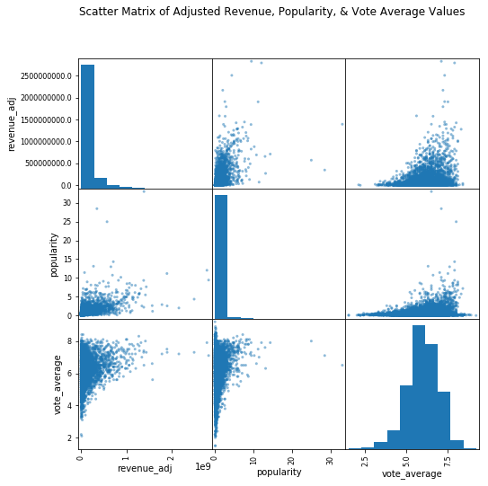

```python
success_metrics = ['revenue_adj', 'popularity', 'vote_average']
pd.plotting.scatter_matrix(df_clean.loc[:,success_metrics], figsize=(8,8));
plt.suptitle("Scatter Matrix of Adjusted Revenue, Popularity, & Vote Average Values");
```

This is actually pretty hard to tell due the number of extreme outliers here. However, given that we are interested in general trends, we can probably work at removing some of those outliers while still preserving the general meaning of the data.

Moreover, in looking at the histograms for 'revenue_adj' and 'popularity', we can see that the distributions were very narrow. We could then get rid of some of the outliers while barely changing the distribution at all. The histogram for 'vote_average' shows a more normal distribution, so it's harder to see where the obvious outliers are. We may be able to leave it the same.

Let's take a pretty basic approach of removing outliers that are 1.5 times the interquartile range on either side of the third quartile.

```python
rev_IQF = 1.5 * (df_clean['revenue_adj'].quantile(0.75) - df_clean['revenue_adj'].quantile(0.25))
rev_outlier_high = df_clean['revenue_adj'].quantile(0.75) + rev_IQF
rev_outlier_low = df_clean['revenue_adj'].quantile(0.25) - rev_IQF
```

```python
pop_IQF = 1.5 * (df_clean['popularity'].quantile(0.75) - df_clean['popularity'].quantile(0.25))
pop_outlier_high = df_clean['popularity'].quantile(0.75) + pop_IQF
pop_outlier_low = df_clean['popularity'].quantile(0.25) - pop_IQF
```

Now let's look at the data with the outliers removed:

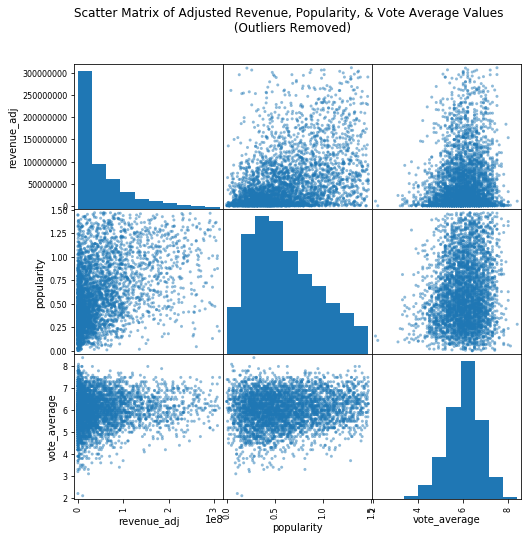

```python
df_success_sansoutliers = df_clean.query('popularity <= @pop_outlier_high & popularity >= @pop_outlier_low \
                                        & revenue_adj <= @rev_outlier_high & revenue_adj >= @rev_outlier_low')
pd.plotting.scatter_matrix(df_success_sansoutliers.loc[:,success_metrics], figsize=(8,8));
plt.suptitle("Scatter Matrix of Adjusted Revenue, Popularity, & Vote Average Values \n (Outliers Removed)");
```

The above is intersting as, in the original scattermatrix, we did as least seemingly notice a slight positive correlation between revenue and vote average, but that's almost gone here. Let's check what % of the data we got rid of when removing those outliers:

```python
(len(df_clean.dropna()) - len(df_success_sansoutliers.dropna())) / len(df_clean.dropna()) * 100
```

```
26.20653866113129
```

Almost 26%, that's a lot! This outlier method isn't working out so well. Out of curiosity, let's see what happens if we ran the same process with a much much stricter outlier definition. Arbitrarily, let's say they have to be 10 times (since so much of our data was in the "outlier" category earlier) the interquartile range away from either third quartile.

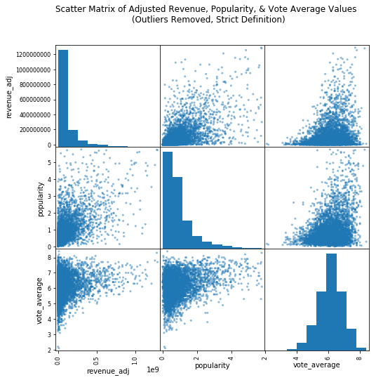

```python
rev_IQF_10 = 10 * (df_clean['revenue_adj'].quantile(0.75) - df_clean['revenue_adj'].quantile(0.25))
rev_outlier_high_10 = df_clean['revenue_adj'].quantile(0.75) + rev_IQF_10
rev_outlier_low_10 = df_clean['revenue_adj'].quantile(0.25) - rev_IQF_10

pop_IQF_10 = 10 * (df_clean['popularity'].quantile(0.75) - df_clean['popularity'].quantile(0.25))
pop_outlier_high_10 = df_clean['popularity'].quantile(0.75) + pop_IQF_10
pop_outlier_low_10 = df_clean['popularity'].quantile(0.25) - pop_IQF_10

df_success_sansoutliers_10 = df_clean.query('popularity <= @pop_outlier_high_10 & popularity >= @pop_outlier_low_10 \
                                        & revenue_adj <= @rev_outlier_high_10 & revenue_adj >= @rev_outlier_low_10')
pd.plotting.scatter_matrix(df_success_sansoutliers_10.loc[:,success_metrics], figsize=(8,8));
plt.suptitle("Scatter Matrix of Adjusted Revenue, Popularity, & Vote Average Values \n (Outliers Removed, Strict Definition)");
```

```python
(len(df_clean.dropna()) - len(df_success_sansoutliers_10.dropna())) / len(df_clean.dropna()) * 100
```

```
1.8681888946549041
```

This result is much more sensible as we recover the relationship between revenue an vote average and only removed ~2% of the data points. Depending on how rigorous we need to be, we could invoke other statistical tests to remove outliers such as utilizing standard deviations instead. But even from this level we can observe the general trend.

First, astoundingly, the movies that brought in the most revenue were not necessarily those with a higher popularity rating. While the highest revenue movie did have a high popularity score, many (with no clear trend) movies with have revenues could be found at all popularity scores. Moreover, a number of high popularity/low revenue movies exist. This is quite unexpected but could be explained if the popularity rating was created by some metric out of touch with actual movie attendance. For instance, if critics viewpoints weighed in more heavily or if a faulty polling metric was used. Overall, while most movies included in this dataset were of medium-to-low popularity AND revenue, there is no clear relationship between the two variables.

Second, there is a slight relationship between vote average and revenue in that revenue is positively (and exponentially) correlated with vote average up unto a score of about 8. After this value, the revenue drops drastically. This also is extremely interesting as it implies movies with the highest ratings on this metric don't actually make the most money. It's possible that such movies are rated as well-crafted movies but don't fall into categories like summer blockbusters that, while not necessarily as artistically excellent, draw in many viewers. Another explanation is that we simply don't have enough examples of >8 vote average to draw good conclusions about revenue (perhaps movies are almost never rated higher than 8).

Explanations for both strange patterns however are purely selective and further information about the success metrics given here, as well as more robust statistical metrics, would be needed to make better argumentation.

### Question 2: How has run-time changed over the years?

We can get a quick sense of this with a scatter plot.

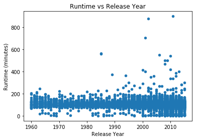

```python
df_clean.plot(x='release_year', y='runtime', kind='scatter', title="Runtime vs Release Year").set(xlabel="Release Year", ylabel="Runtime (minutes)");
```

But let's remove some outliers using the interquartile range setup like before. Then let's print out some statistics on runtime for curiosity.

```
count    10156.000000
mean       101.006892
std         15.073082
min         57.000000
25%         90.000000
50%         99.000000
75%        110.000000
max        145.000000
Name: runtime, dtype: float64
```

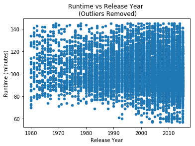

```python
time_IQF = 1.5 * (df_clean['runtime'].quantile(0.75) - df_clean['runtime'].quantile(0.25))
time_outlier_high = df_clean['runtime'].quantile(0.75) + time_IQF
time_outlier_low = df_clean['runtime'].quantile(0.25) - time_IQF
df_runtime_sansoutliers = df_clean.query('runtime <= @time_outlier_high & runtime >= @time_outlier_low')
df_runtime_sansoutliers.plot(x='release_year', y='runtime', kind='scatter', title="Runtime vs Release Year \n (Outliers Removed)").set(xlabel="Release Year", ylabel="Runtime (minutes)");
print(df_runtime_sansoutliers['runtime'].describe())
```

The statistics printed for runtime look pretty reasonable (the minimum and maximum run times look within conventional movie norms), so the data we're now working with is likely reasonable.

When looking at the plot however, the relationship is in the least not obvious. For the most part, it seems there is no true relationship between movie runtime and release year. There is a slight fanning out of the data points towards 2010 and onwards, so a robust statistical analysis might determine that variance of runtimes has increased over the years, but that is beyond the scope of this project.

### Question 3: What are the general distributions and characteristics of movie budgets, revenue, and runtime?

*First for movie budgets:*

```
count    5.169000e+03
mean     3.688907e+07
std      4.196096e+07
min      9.210911e-01
25%      8.102293e+06
50%      2.271505e+07
75%      5.008384e+07
max      4.250000e+08
Name: budget_adj, dtype: float64
```

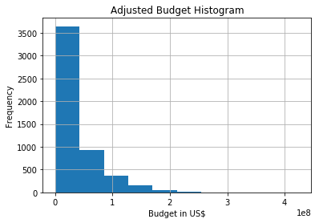

```python
print(df_clean['budget_adj'].describe())
df_clean['budget_adj'].hist().set(title="Adjusted Budget Histogram", xlabel="Budget in US$", ylabel="Frequency");
```

Most budgets appear to have been small relative to high-budget movies as apparent from the histogram, generally costing less than 50,000,000 dollars.

One of the movies apparently had a budget of less than a dollar though (from the .describe() info). Let's look at that one.

```python
min_budget_movie = df_clean['budget_adj'].idxmin()
df_clean.loc[min_budget_movie]
```

```
popularity                   0.177102
original_title            Fear Clinic
runtime                            95
release_date      2014-10-31 00:00:00
vote_count                         15
vote_average                      4.1
release_year                     2014
budget_adj                   0.921091
revenue_adj                       NaN
Name: 287524, dtype: object
```

I looked up this movie on wikipedia (https://en.wikipedia.org/wiki/Fear_Clinic_(film)) and indeed the budget in the dataframe is incorrect. It's rather listed as 1.1 million dollars. That's concerning as it implies that maybe a lot of the budget values were entered in on the wrong scale. For instance, in the above, maybe "0.921" is supposed to be that number in millions. Let's do a check of our budget to see how many values are very low. Conceivably we could actually have so very low budget movies that only cost a few hundred dollars to make, but we shouldn't expect any significant portion of our dataset to be this way. Let's look for all those less than $1,000 to satisfy our worry.

```python
len(df_clean.query('budget_adj <= 1000'))
```

```
58
```

*Now for revenue:*

```
count    4.849000e+03
mean     1.151009e+08
std      1.988557e+08
min      2.370705e+00
25%      1.046585e+07
50%      4.395666e+07
75%      1.316482e+08
max      2.827124e+09
Name: revenue_adj, dtype: float64
```

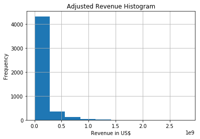

```python
print(df_clean['revenue_adj'].describe())
df_clean['revenue_adj'].hist().set(title="Adjusted Revenue Histogram", xlabel="Revenue in US$", ylabel="Frequency");
```

```python
len(df_clean.query('revenue_adj <= 1000'))
```

```
51
```

Since asking for the lowest revenues doesn't return meaningful data here, let's ask for the highest revenue movie out of curiosity.

```python
max_rev_movie = df_clean['revenue_adj'].idxmax()
df_clean.loc[max_rev_movie]
```

```
popularity                    9.43277
original_title                 Avatar
runtime                           162
release_date      2009-12-10 00:00:00
vote_count                       8458
vote_average                      7.1
release_year                     2009
budget_adj                2.40887e+08
revenue_adj               2.82712e+09
Name: 19995, dtype: object
```

I've seen this movie! It also makes perfect sense. Avatar grossed gigantic amounts of money when it came out. Out of curiosity, let's take a guess at whether they really made a profit. This may not be accurate as their actual money spent may not be equal to the budget, but it's an estimate.

```python
df_clean.loc[max_rev_movie, 'revenue_adj'] -df_clean.loc[max_rev_movie, 'budget_adj']
```

```
2586236847.524277
```

Looks like they made a ton!

*Finally for runtime:*

```
count    10834.000000
mean       102.363855
std         30.948225
min          2.000000
25%         90.000000
50%         99.000000
75%        112.000000
max        900.000000
Name: runtime, dtype: float64
```

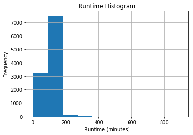

```python
print(df_clean['runtime'].describe())
df_clean['runtime'].hist().set(title="Runtime Histogram", xlabel="Runtime (minutes)", ylabel="Frequency");
```

Most of the values fall around 200 minutes or less, but there are some interesting minimums (2 minutes) and maximums (900 minutes) here. Let's check those.

```python
min_runtime_movie = df_clean['runtime'].idxmin()
print(df_clean.loc[min_runtime_movie])
max_runtime_movie = df_clean['runtime'].idxmax()
print(df_clean.loc[max_runtime_movie])
```

```
popularity                    0.002757
original_title    Bambi Meets Godzilla
runtime                              2
release_date       1969-01-01 00:00:00
vote_count                          12
vote_average                       5.6
release_year                      1969
budget_adj                         NaN
revenue_adj                        NaN
Name: 3171, dtype: object
popularity                             0.006925
original_title    The Story of Film: An Odyssey
runtime                                     900
release_date                2011-09-03 00:00:00
vote_count                                   14
vote_average                                9.2
release_year                               2011
budget_adj                                  NaN
revenue_adj                                 NaN
Name: 125336, dtype: object
```

I looked these up on wikipedia and apparently these values are accurate. The two movies really did have runtimes with these values, so it seems our dataset is safe. It does mean it apparently includes both shorts (like "Bambi Meets Godzilla") and long documentaries (like "The Story of Film") and not just traditional movies however.